# Untitled

A new article created using the ucsc Distill format.

# Introduzione

Distill è un tipo do formato di pubblicazione per documenti scientifici e/o tecnici nativo web.

Impara qualcosa di più su Distill per R Markdown su https://rstudio.github.io/distill.

Quello che trovi qui è un template riafdattato da Niccolò Salvini per pubblicazioni da Cattolica.

Gli articoli in Distill includono le seguenti features:

- Tipografia adatta ai lettori che si adatta bene ai dispositivi mobili.
- Funzionalità essenziali per la scrittura tecnica come la matematica, le citazioni e le note a piè di pagina di LaTeX.
- Opzioni flessibili di layout delle figure (ad es. visualizzazione di figure con una larghezza maggiore rispetto al testo dell’articolo).
- Tabelle renderizzate in modo attraente con supporto opzionale per l’impaginazione.
- Supporto per un’ampia varietà di strumenti per la creazione di diagrammi per l’illustrazione di concetti.
- La possibilità di incorporare visualizzazioni interattive basate su JavaScript e D3.
- Una varietà di modi per pubblicare articoli, incluso il supporto per la pubblicazione di set di articoli come sito Web Distill o blog Distill.

## Scrivi un articolo

e selezionare distill article.

# yaml options

I nomi degli autori possono essere specificati utilizzando i campi nome e cognome espliciti o con un campo nome singolo. Le voci dell’autore devono avere almeno un nome e un URL specificati (i campi di affiliazione sono facoltativi). Specificare l’ID Orcid di un autore utilizzando il campo orcid_id.

La descrizione dell’articolo e i sottotitoli dell’autore vengono visualizzati automaticamente come parte dell’area del titolo del documento.

Il campo della data deve essere formattato come mese, giorno, anno o come anno, mese, giorno (sono supportate varie notazioni purché i componenti appaiano in uno di questi ordini).

Il campo bibliografia viene utilizzato per fornire un riferimento al file Bibtex in cui sono definite tutte le fonti citate nel tuo articolo. La sezione citazioni descrive come includere riferimenti a queste fonti nel tuo articolo.

# utilizzo

# Figure

Ad esempio, se volessimo visualizzare una figura un po’ fuori dai limiti del testo dell’articolo, potremmo specificare il layout l-body-outset tramite l’opzione layout chunk:

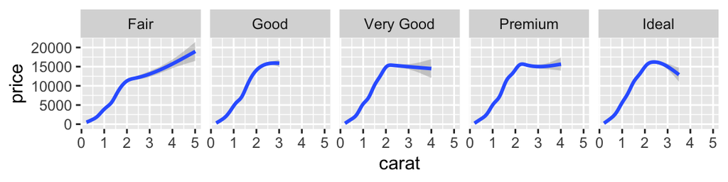

```r
library(ggplot2)
ggplot(diamonds, aes(carat, price)) + geom_smooth() +
  facet_grid(~ cut)
```

Si noti che quando si specifica un layout alternativo è necessario specificare anche fig.width e fig.height per quel layout. Questi valori non determinano la dimensione assoluta della figura (che è dinamica in base al layout) ma determinano le proporzioni della figura.

Vedere la documentazione sul layout delle figure per i dettagli sulle opzioni di layout aggiuntive.

Gli esempi sopra si basano su grafici R convenzionali. Gli articoli Distill possono anche incorporare diagrammi e visualizzazioni interattive basate su JavaScript e D3.

# le equazioni

Le equazioni inline e di visualizzazione sono supportate tramite la sintassi MathJax markdown standard. Ad esempio, la seguente matematica LaTeX:

> `$$ \sigma = \sqrt{ \frac{1}{N} \sum_{i=1}^N (x_i -\mu)^2}`$$

che sarà renderizzata come:

$$\sigma = \sqrt{ \frac{1}{N} \sum_{i=1}^N (x_i -\mu)^2}$$